# Zadanie domowe - EDA Danych dotyczących Irysów

- Twoim zadaniem jest wykonanie analizy danych zawartych w załączonym pliku CSV (`25__iris.csv`).
- Plik znajduje się pod video. Pamiętaj, żeby wrzucić plik do tego samego folderu, w którym znajduje się ten notebook.
- Wykorzystaj nowo nabytą wiedzę z biblioteki `Pandas`
- Jeżeli jest taka konieczność posiłkuj się [code explainerem](https://codeexplainer.imprv.ai/) lub / i [data chatterem](https://datachatter.imprv.ai/) (który również te dane ma dostępne).
- Prześlij na discordzie notebook z rozwiązaniem (`#modul-4-zad1`)
- Pamiętaj:
1. Nie spiesz się
2. Potraktuj zadanie domowe jak prawdziwy projekt
3. Dodawaj opisy, obserwacje, wnioski
4. Dodaj wizualizacje
5. Dodaj konkluzję i wnioski końcowe

Powodzenia!!! I mega zabawy!

## O Danych

Zbiór danych zawiera informacje o trzech gatunkach irysów: Iris setosa, Iris versicolor, i Iris virginica.

Dane obejmują pomiary czterech cech: długość i szerokość działki kielicha oraz długość i szerokość płatka.

Każdy wiersz w zbiorze danych reprezentuje pojedynczy kwiat, a wartości pomiarów są podane w centymetrach.

Zbiór składa się z 150 próbek, po 50 dla każdego gatunku, i jest szeroko stosowany jako podstawowy zbiór danych do testowania algorytmów klasyfikacji oraz w nauce o danych i uczeniu maszynowym.

Kolumny:

- **długość kielicha (sepal length)** - Długość kielicha w cm
- **szerokość kielicha (sepal width)** - Szerokość kielicha w cm
- **długość płatka (petal length)** - Długość płatka w cm
- **szerokość płatka (petal width)** - Szerokość płatka w cm
- **klasa (class)** - Klasa irysa (setosa, versicolor, virginica)

```python
import pandas as pd
import matplotlib.pyplot as plt
import seaborn as sns
```

```python
df = pd.read_csv('25__iris.csv', sep=",")
df
```

|  | długość kielicha (sepal length) | szerokość kielicha (sepal width) | długość płatka (petal length) | szerokość płatka (petal width) | klasa (class) |
| --- | --- | --- | --- | --- | --- |
| 0 | 5.1 | 3.5 | 1.4 | 0.2 | Iris-setosa |
| 1 | 4.9 | 3.0 | 1.4 | 0.2 | Iris-setosa |
| 2 | 4.7 | 3.2 | 1.3 | 0.2 | Iris-setosa |
| 3 | 4.6 | 3.1 | 1.5 | 0.2 | Iris-setosa |
| 4 | 5.0 | 3.6 | 1.4 | 0.2 | Iris-setosa |
| ... | ... | ... | ... | ... | ... |
| 145 | 6.7 | 3.0 | 5.2 | 2.3 | Iris-virginica |
| 146 | 6.3 | 2.5 | 5.0 | 1.9 | Iris-virginica |
| 147 | 6.5 | 3.0 | 5.2 | 2.0 | Iris-virginica |
| 148 | 6.2 | 3.4 | 5.4 | 2.3 | Iris-virginica |
| 149 | 5.9 | 3.0 | 5.1 | 1.8 | Iris-virginica |

150 rows × 5 columns

```python
df.sample(10)
```

|  | długość kielicha (sepal length) | szerokość kielicha (sepal width) | długość płatka (petal length) | szerokość płatka (petal width) | klasa (class) |
| --- | --- | --- | --- | --- | --- |
| 0 | 5.1 | 3.5 | 1.4 | 0.2 | Iris-setosa |
| 15 | 5.7 | 4.4 | 1.5 | 0.4 | Iris-setosa |
| 121 | 5.6 | 2.8 | 4.9 | 2.0 | Iris-virginica |
| 127 | 6.1 | 3.0 | 4.9 | 1.8 | Iris-virginica |
| 87 | 6.3 | 2.3 | 4.4 | 1.3 | Iris-versicolor |
| 88 | 5.6 | 3.0 | 4.1 | 1.3 | Iris-versicolor |
| 67 | 5.8 | 2.7 | 4.1 | 1.0 | Iris-versicolor |
| 13 | 4.3 | 3.0 | 1.1 | 0.1 | Iris-setosa |
| 1 | 4.9 | 3.0 | 1.4 | 0.2 | Iris-setosa |
| 82 | 5.8 | 2.7 | 3.9 | 1.2 | Iris-versicolor |

```python
df.info()
```

```
<class 'pandas.core.frame.DataFrame'>
RangeIndex: 150 entries, 0 to 149
Data columns (total 5 columns):
 #   Column                            Non-Null Count  Dtype
---  ------                            --------------  -----
 0   długość kielicha (sepal length)   150 non-null    float64
 1   szerokość kielicha (sepal width)  150 non-null    float64
 2   długość płatka (petal length)     150 non-null    float64
 3   szerokość płatka (petal width)    150 non-null    float64
 4   klasa (class)                     150 non-null    object
dtypes: float64(4), object(1)
memory usage: 6.0+ KB
```

## Wnioski:

- **Wszystkie wartości są uzupełnione (Brak pustych). Typy float i jedna kolumna object**

```python
df.describe()
```

|  | długość kielicha (sepal length) | szerokość kielicha (sepal width) | długość płatka (petal length) | szerokość płatka (petal width) |
| --- | --- | --- | --- | --- |
| count | 150.000000 | 150.000000 | 150.000000 | 150.000000 |
| mean | 5.843333 | 3.054000 | 3.758667 | 1.198667 |
| std | 0.828066 | 0.433594 | 1.764420 | 0.763161 |
| min | 4.300000 | 2.000000 | 1.000000 | 0.100000 |
| 25% | 5.100000 | 2.800000 | 1.600000 | 0.300000 |
| 50% | 5.800000 | 3.000000 | 4.350000 | 1.300000 |
| 75% | 6.400000 | 3.300000 | 5.100000 | 1.800000 |
| max | 7.900000 | 4.400000 | 6.900000 | 2.500000 |

## Wnioski:

1. Kielich
2. Płatek
> - **Najmniejsza długość kielicha to 4,3 cm, największa 7,9 cm**
> - **Najmniejsza szerokość kielicha to 2 cm, największa 4,4 cm**
> - **Najmniejsza długość płatka to 1 cm, największa 6,9 cm**
> - **Najmniejsza szerokość płatka to 0,1 cm, największa 2,5 cm**

```python
df.nunique()
```

```
długość kielicha (sepal length)     35
szerokość kielicha (sepal width)    23
długość płatka (petal length)       43
szerokość płatka (petal width)      22
klasa (class)                        3
dtype: int64
```

## Wnioski:

> - *Największe z różnicowania występują pod względem:*

> **Dłogości Płatka(petal lengh)** a następnie **Długości Kielicha(sepal lengh)**

```python
df.corr()
```

|  | długość kielicha (sepal length) | szerokość kielicha (sepal width) | długość płatka (petal length) | szerokość płatka (petal width) |
| --- | --- | --- | --- | --- |
| długość kielicha (sepal length) | 1.000000 | -0.109369 | 0.871754 | 0.817954 |
| szerokość kielicha (sepal width) | -0.109369 | 1.000000 | -0.420516 | -0.356544 |
| długość płatka (petal length) | 0.871754 | -0.420516 | 1.000000 | 0.962757 |
| szerokość płatka (petal width) | 0.817954 | -0.356544 | 0.962757 | 1.000000 |

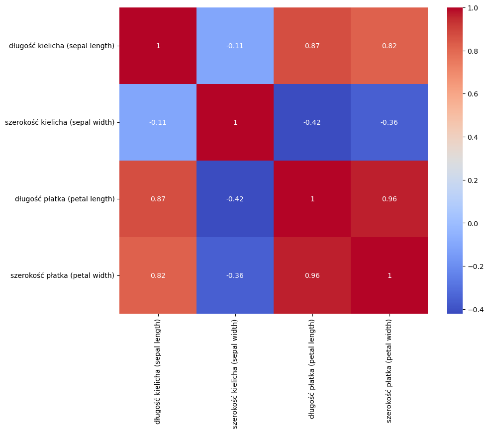

```python
correlation_matrix = df.corr()

plt.figure(figsize=(10, 8))
sns.heatmap(correlation_matrix, annot=True, cmap='coolwarm')
plt.savefig('correlation_heatmap.png')
```

## Wnioski:

1. Mocna korelacja dodatnia występuje dla
2. Drugą mocną korelacją dodatnią jest
> - **szerokość płatka i jego długość**
> - **Długość i szerokość płatka z długością kielicha**

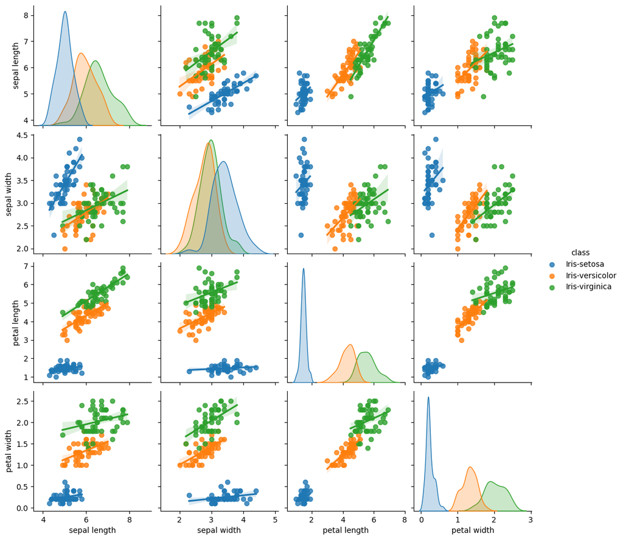

```python
df = df

df.columns = ['sepal length', 'sepal width', 'petal length', 'petal width', 'class']

pairplot = sns.pairplot(df, kind='reg', diag_kind='kde', hue='class')

plot_filename = "pairplot_with_regression.png"
pairplot.savefig(plot_filename)

result = { "type": "plot", "value": plot_filename }
```

## Wnioski:

1. Odmiana Iris-setosa odbiega od pozostałych dwóch gatunków które są bardziej zbliżone do siebie
2. Najdłuższe kielichy maja kolejno: iris-virginica, versicolor, setosa
3. Iris-setosa ma dośc szerokie kielichy przy małej ich długości, następnie virginica, versicolor
4. Pod względem długości i szerokości płatków dominują iris-virginica, versicolor i na końcu setosa

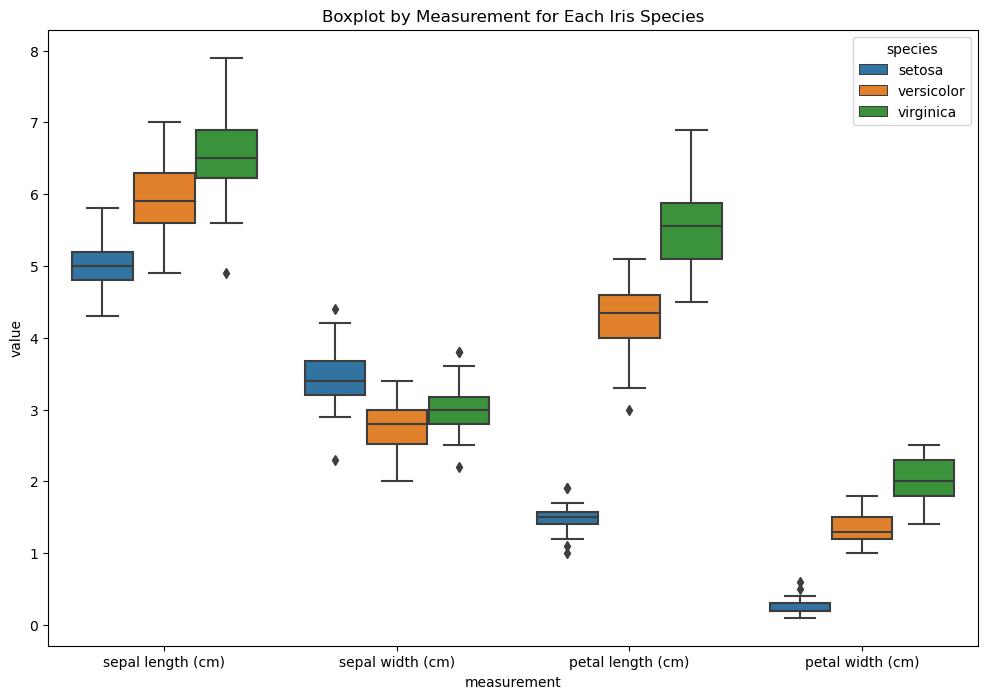

```python
from sklearn.datasets import load_iris

# Load the Iris dataset from sklearn
iris_dataset = load_iris()
iris_df = pd.DataFrame(data=iris_dataset.data, columns=iris_dataset.feature_names)
iris_df['species'] = pd.Categorical.from_codes(iris_dataset.target, iris_dataset.target_names)

# Melt the dataframe for better usage in seaborn
iris_melted = iris_df.melt(id_vars='species', var_name='measurement', value_name='value')

# Create the boxplot
plt.figure(figsize=(12, 8))
sns.boxplot(x='measurement', y='value', hue='species', data=iris_melted)
plt.title('Boxplot by Measurement for Each Iris Species')
plt.show()
```

## Podsumowanie użytkowe dla klienta:

1. Aby utworzyć wysokie rabaty widoczne z dużej odległości skorzystałbym z Iris-Virginica ponieważ maja najdłuższe kielichy i najdłuższe i najszersze płatki
2. W przypadku tworzenia rabat gęstych skorzystałbym z Iris-Setosa ze względu na najmniejsze rozmiarydługości kielicha, szerokości i długości płatka co może sprawiać że rabaty kwiatowe moga wydawać się zagęszczone co do ilości kwiatów na 1 m kwadratowy
3. Pod względem kolorystycznym projektowanych rabat wybrałbym Iris-Versicolor ze względu na różnorodnośc kolorów.